# rgugik: pobieranie danych z GUGiK w R

Krzysztof Dyba, Jakub Nowosad

2020-08-23

# Wstęp

**R**, tuż obok **Pythona**, jest jednym z najbardziej popularnych języków programowania używanych do analizy danych. **R** znalazł szczególne zastosowanie w takich dziedzinach jak ekologia, leśnictwo, hydrologia czy teledetekcja dzięki swojej prostocie, automatyzacji oraz ogromnemu wsparciu przez jego społeczność. Jest również używany w profesjonalnych zastosowaniach przez takie firmy jak [Microsoft, Facebook, Twitter czy Google](https://github.com/ThinkR-open/companies-using-r#readme).

Niniejszy poradnik prezentuje w jaki sposób pozyskać najpopularniejsze dane przestrzenne, tj. ortofotomapy i Cyfrowe Modele Wysokościowe z zasobów [Głównego Urzędu Geodezji i Kartografii](http://www.gugik.gov.pl/) używając języka **R** i pakietu **rgugik**. Dodatkowo, zawiera on praktyczne przykłady wykorzystania tych danych.

Jeśli chciałbyś rozszerzyć swoją wiedzę i zdobyć praktyczne umiejętności analizy danych nieprzestrzennych, to zachęcamy do uczestnictwa w [bezpłatnym kursie online](http://pogromcydanych.icm.edu.pl) przygotowanym przez [Uniwersytet Warszawski](https://www.icm.edu.pl) dla początkujących w języku polskim lub przeczytania książki [Elementarz programisty: Wstęp do programowania używając R](https://nowosad.github.io/elp/). Więcej na temat analizy danych przestrzennych można natomiast przeczytać po angielsku na stronie [Geocomputation with R](https://geocompr.robinlovelace.net/).

# Instalacja

Niezbędnym narzędziem w tym poradniku będzie interpreter **R**, który można pobrać na system:

- [Windows](https://cloud.r-project.org/bin/windows/base/R-4.0.2-win.exe)
- [Linux](https://cloud.r-project.org/)
- [Mac OS](https://cloud.r-project.org/)

Dodatkowo, pomocnym narzędziem jest edytor kodu - RStudio, który można pobrać z [tego](https://rstudio.com/products/rstudio/download/#download) miejsca dla różnych systemów operacyjnych. Oba te programy są całkowicie **darmowe**, a ich instalacja przebiega w standardowy sposób.

# Pierwsze uruchomienie

Uruchamiamy RStudio i wybieramy *File > New Project… > New Directory > New Project*. W ostatnim oknie podajemy nazwę nowego folderu (np. `dane_gugik`) oraz jego lokalizację (np. Moje Dokumenty). Następnie klikamy *File > New File > R Script* (lub kombinacja klawiszy “*CTRL + SHIFT + N*”). Otworzy się nowe puste okienko i możemy przystąpić do pisania naszego kodu.

Na początku musimy zainstalować potrzebne pakiety. Do instalacji nowych pakietów służy funkcja `install.packages()`.

```r
pakiety = c("sf", "raster", "remotes")
install.packages(pakiety)
```

Do zmiennej `pakiety` przypisaliśmy trzy nazwy pakietów (zbiorów dodatkowych funkcji) w R: **sf** obsługuje dane wektorowe, **raster** dane rastrowe, a pakiet **remotes** umożliwi pobranie nam wesji testowej pakietu **rgugik**.

```r
remotes::install_github("kadyb/rgugik")
```

Powyższa linia kodu pobierze najnowszą wersję pakietu **rgugik**, który umożliwia przeszukiwanie i pobieranie danych z zasobów GUGiK.

# Wczytanie danych

Zacznijmy od pobrania i wczytania danych bez używania pakietu **rgugik**. Ze strony Generalnej Dyrekcji Ochrony Środowiska pobierzmy dane wektorowe zawierające [rezerwaty przyrody](http://sdi.gdos.gov.pl/wfs?SERVICE=WFS&VERSION=1.0.0&REQUEST=GetFeature&TYPENAME=GDOS:Rezerwaty&SRSNAME=EPSG:2180&outputFormat=shape-zip&format_options=charset:windows-1250) w formacie `.shp`. Rozpakujmy je do podfolderu o tej samej nazwie (`"Rezerwaty"`) w głównym folderze `dane_gugik`.

W kolejnym kroku załadujmy pakiety, które zainstalowaliśmy wcześniej. Do tego celu służy funkcja `library()`.

```r
library(sf)
library(raster)
```

Teraz wczytajmy nasze dane przy pomocy funkcji `read_sf()`, która jako argument przyjmuje ścieżkę do pliku. Oprócz tego, musimy ustawić odpowiednie kodowanie polskich znaków (*WINDOWS-1250*) jako argument tej funkcji.

```r
rezerwaty = read_sf("Rezerwaty/RezerwatyPolygon.shp",
                    options = "ENCODING=WINDOWS-1250")
```

Sprawdźmy jak wygląda struktura naszych danych:

```r
head(rezerwaty)
```

| gid | nazwa | kodinspire | geometry |
| --- | --- | --- | --- |
| 2509 | Jezioro Łuknajno | PL.ZIPOP.1393.RP.1113 | MULTIPOLYGON (((674824.2 66… |
| 2510 | Stary Czapliniec | PL.ZIPOP.1393.RP.28 | MULTIPOLYGON (((676241.8 66… |
| 2511 | Rezerwat Skalny im. Jana Czarnockiego | PL.ZIPOP.1393.RP.1031 | MULTIPOLYGON (((611690.8 33… |
| 2512 | Jata | PL.ZIPOP.1393.RP.1126 | MULTIPOLYGON (((721593.2 45… |
| 2513 | Dębina | PL.ZIPOP.1393.RP.30 | MULTIPOLYGON (((661007.4 50… |
| 2514 | Jedlina | PL.ZIPOP.1393.RP.14 | MULTIPOLYGON (((684158.7 47… |

Jest to tabela (ramka danych) składająca się z czterech kolumn (`gid`, `nazwa`, `kodinspire` oraz `geometry`) i 1674 obiektów (rezerwatów przyrody).

Na potrzebny analizy wybierzmy sobie jeden - [rezerwat Krajkowo](https://pl.wikipedia.org/wiki/Rezerwat_przyrody_Krajkowo) położony w województwie wielkopolskim.

```r
# selekcja poprzez atrybut
krajkowo = rezerwaty[rezerwaty$nazwa == "Krajkowo", ]
```

Wyświetlić geometrię poligonu możemy na dwa sposoby:

1. Wykorzystując funkcję `plot` i bezpośrednio podając kolumnę z geometrią obiektu: `plot(krajkowo$geometry)`
2. Wykorzystując funkcje `plot` oraz `st_geometry`, która pozyska geometrię z poligonu. W przypadku pierwszym musimy znać nazwę kolumny z geometrią, natomiast w drugim przypadku geometria zostanie przekazana automatycznie (jest to bezpieczniejszy sposób).

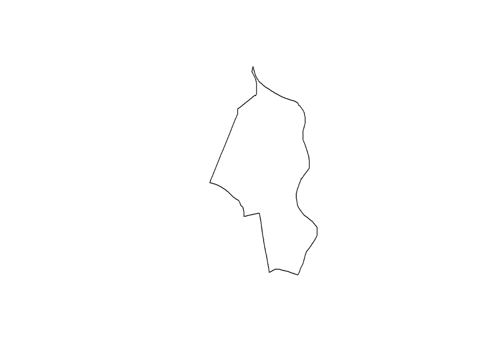

```r
# najpierw pobieramy geometrię obiektu,
# a następnie wyświetlamy ją (funkcja zagnieżdżona)
plot(st_geometry(krajkowo))
```

# Ortofotomapa

## Pobieranie

Do pobrania danych ortofoto użyjemy pakietu **rgugik**. Załadujemy go do R identycznie jak poprzednie pakiety używając funkcji `library()`.

```r
library(rgugik)
```

Następnie wykorzystamy funkcję `orto_request()`, która pokaże nam jakie są dostępne ortoobrazy na analizowanym obszarze. Jako argument tej funkcji podamy nasz poligon Krajkowo (obiekt `krajkowo`).

```r
req_df = orto_request(krajkowo)
```

Tabelę wynikową z dostępnymi ortoobrazami możemy wyświetlić używając poniższego kodu[^1].

```r
# wyświetlamy 10 pierwszych wyników oraz 6 pierwszych kolumn
req_df[1:10, 1:6]
```

| sheetID | year | resolution | composition | sensor | CRS |
| --- | --- | --- | --- | --- | --- |
| N-33-142-B-d-4-2 | 2004 | 0.50 | B/W | Analog | PL-1992 |
| N-33-142-B-d-4-4 | 2004 | 0.50 | B/W | Analog | PL-1992 |
| N-33-142-B-d-4-4 | 2010 | 0.25 | RGB | Digital | PL-1992 |
| N-33-142-B-d-4-2 | 2010 | 0.25 | RGB | Digital | PL-1992 |
| N-33-142-B-d-4-4 | 2010 | 0.25 | CIR | Digital | PL-1992 |
| N-33-142-B-d-4-2 | 2010 | 0.25 | CIR | Digital | PL-1992 |
| N-33-142-B-d-4-2 | 2016 | 0.25 | CIR | Digital | PL-1992 |
| N-33-142-B-d-4-2 | 2016 | 0.25 | RGB | Digital | PL-1992 |
| N-33-142-B-d-4-4 | 2016 | 0.25 | CIR | Digital | PL-1992 |
| N-33-142-B-d-4-4 | 2016 | 0.25 | RGB | Digital | PL-1992 |

W ramach ćwiczeń pobierzemy kompozycję w podczerwieni obrazującą najbardziej aktualne dane. Mamy już naszą tabelę z dostępnymi ortoobrazami (`req_df`), więc w kolejnym kroku możemy dokonać selekcji poprzez wybór tych wierszy, dla których kolumna `composition` przyjmuje wartość `"CIR"`.

```r
# wybieramy obrazy w podczerwieni i nadpisujemy obiekt req_df
req_df = req_df[req_df$composition == "CIR", ]
```

Następnie posortujmy tabelę według roku wykonania zdjęcia, gdzie na początku znajdą się te najaktualniejsze zobrazowania.

```r
# minus oznacza kolejność malejącą
req_df = req_df[order(-req_df$year), ]
```

Wyświetlmy tabelę ponownie i wybierzmy najnowsze kompozycje.

```r
req_df[, 1:6]
```

|  | sheetID | year | resolution | composition | sensor | CRS |
| --- | --- | --- | --- | --- | --- | --- |
| 7 | N-33-142-B-d-4-2 | 2016 | 0.25 | CIR | Digital | PL-1992 |
| 9 | N-33-142-B-d-4-4 | 2016 | 0.25 | CIR | Digital | PL-1992 |
| 22 | N-33-142-B-d-4-2 | 2013 | 0.25 | CIR | Digital | PL-1992 |
| 24 | N-33-142-B-d-4-4 | 2013 | 0.25 | CIR | Digital | PL-1992 |
| 5 | N-33-142-B-d-4-4 | 2010 | 0.25 | CIR | Digital | PL-1992 |
| 6 | N-33-142-B-d-4-2 | 2010 | 0.25 | CIR | Digital | PL-1992 |

```r
req_df = req_df[req_df$year == 2016, ]
```

Zwróćmy uwagę, że w wyniku otrzymaliśmy dwa obiekty (obrazy). Oznacza to, że nasz rezerwat Krajkowo jest zobrazowany na dwóch zdjęciach w ramach jednej serii. Atrybut *seriesID* służy więc do łączenia mniejszych obrazów w większe mozaiki.

```r
# wybór kolumn (atrybutów) poprzez ich indeks
# 1: "sheetID", 2: "year", 3: "resolution", itd.
# zostały wybrane kolumny od 1 do 6 oraz 9
req_df[, c(1:6, 9)]
```

|  | sheetID | year | resolution | composition | sensor | CRS | seriesID |
| --- | --- | --- | --- | --- | --- | --- | --- |
| 7 | N-33-142-B-d-4-2 | 2016 | 0.25 | CIR | Digital | PL-1992 | 69837 |
| 9 | N-33-142-B-d-4-4 | 2016 | 0.25 | CIR | Digital | PL-1992 | 69837 |

Do pobrania ortoobrazow z serwerów GUGiK służy funkcja `tile_download()`, która jako główny argument przyjmuje naszą wyselekcjonowaną tabelę.

Pobierane dane domyślnie zapisywane są do aktualnego katalogu roboczego[^2].

```r
tile_download(req_df)
```

## Przetwarzanie

Wczytajmy pobrane ortoobrazy za pomocą funkcji `brick()` z pakietu **raster**, która umożliwia ona pracę na rastrach składających się z kilku kanałów - w naszym przypadku trzech: NIR, R, G.

```r
img1 = brick("69837_329609_N-33-142-B-d-4-2.TIF")
img2 = brick("69837_329613_N-33-142-B-d-4-4.TIF")
```

Następnie przeprowadzimy operacje: połączenia, docięcia do obszaru rezerwatu i zamaskowania pikseli poza zasięgiem poligonu. Ten proces może zająć kilka minut.

```r
# łączenie rastrów
img = merge(img1, img2)
# docięcie rastrów do poligonu
img = crop(img, krajkowo)
# zamaskowanie pikseli poza poligonem
img = mask(img, krajkowo)
```

Wyświetlmy efekt końcowy używając funkcji `plotRGB()`. Funkcja `plotRGB()` tworzy wizualizację poprzez połączenie wartości trzech warstw rastrowych. Poniższa kompozycja przedstawiona jest w podczerwieni, a nie w barwach naturalnych, co może mylnie interpretować z nazwy funkcji.

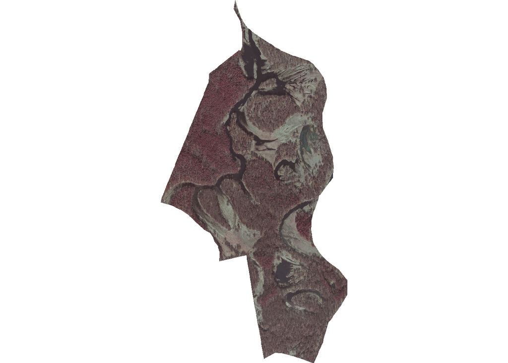

```r
plotRGB(img)
```

W ostatnim kroku obliczmy wskaźnik znormalizowany różnicowy wskaźnik wegetacji [NDVI](https://pl.wikipedia.org/wiki/Znormalizowany_r%C3%B3%C5%BCnicowy_wska%C5%BAnik_wegetacji) wykorzystując kanały podczerwieni (1) i czerwieni (2).

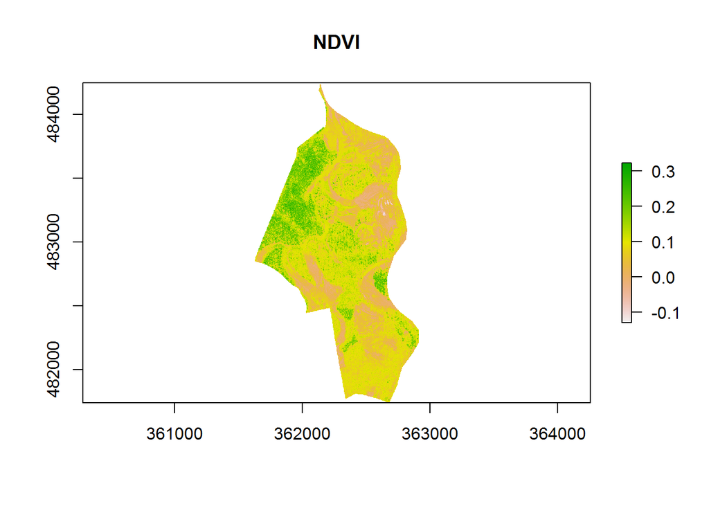

```r
ndvi = (img[[1]] - img[[2]]) / (img[[1]] + img[[2]])
plot(ndvi, main = "NDVI")
```

Zadziwiającym spostrzeżeniem są względnie niskie wartości NDVI dla obszaru leśnego. Przyczyny są dwie, tj. zdjęcia wykonywane są w okresie jesiennym oraz prawdopodobnie nie zostały skalibrowane. Z tego powodu lepszym źródłem danych do analiz mogą być zdjęcia satelitarne, które podlegają kalibracji spektralnej i stanowią ciągły zasób danych (jeśli nie wystąpi zachmurzenie).

# Cyfrowe Modele Wysokościowe

## Pobieranie

W tej sekcji przeprowadzimy analogiczną procedurę, ale tym razem pobierzemy dane wysokościowe dla tego samego obszaru. Funkcja, która nam do tego posłuży to `DEM_request()` działająca identycznie jak `orto_request()`.

```r
req_df = DEM_request(krajkowo)
```

Do analizy wykorzystamy Numeryczny Model Terenu (DTM) oraz Numeryczny Model Pokrycia Terenu (DSM). Posłużą one do obliczenia wysokości drzew i budynków. Aby ułatwić selekcje danych, stworzymy dwie tabele, a na końcu je złączymy.

```r
req_df_DTM = req_df[req_df$format == "ARC/INFO ASCII GRID" &
                    req_df$product == "DTM" &
                    req_df$year == 2011, ]
req_df_DSM = req_df[req_df$format == "ARC/INFO ASCII GRID" &
                    req_df$product == "DSM" &
                    req_df$year == 2011, ]
# łączenie tabel
req_df = rbind(req_df_DTM, req_df_DSM)
req_df[, 1:6]
```

|  | sheetID | year | format | resolution | avgElevErr | CRS |
| --- | --- | --- | --- | --- | --- | --- |
| 3 | N-33-142-B-d-4-2 | 2011 | ARC/INFO ASCII GRID | 1.0 m | 0.15 | PL-1992 |
| 4 | N-33-142-B-d-4-4 | 2011 | ARC/INFO ASCII GRID | 1.0 m | 0.15 | PL-1992 |
| 7 | N-33-142-B-d-4-2 | 2011 | ARC/INFO ASCII GRID | 1.0 m | 0.15 | PL-1992 |
| 8 | N-33-142-B-d-4-4 | 2011 | ARC/INFO ASCII GRID | 1.0 m | 0.15 | PL-1992 |

Pobierzmy dane ponownie używając `tile_download()`.

```r
tile_download(req_df)
```

## Przetwarzanie

Wczytajmy je za pomocą funkcji `raster()` (w odróżnieniu od funkcji `brick()` wczytuje tylko rastry składające się z jednego kanału).

```r
# DTM
DTM1 = raster("4072_8123_N-33-142-B-d-4-2.asc")
DTM2 = raster("4072_8125_N-33-142-B-d-4-4.asc")

# DSM
DSM1 = raster("3182_10015_N-33-142-B-d-4-2.asc")
DSM2 = raster("3182_10017_N-33-142-B-d-4-4.asc")
```

Połączmy nasze rastry.

```r
DTM = merge(DTM1, DTM2)
DSM = merge(DSM1, DSM2)
```

Nałóżmy je na siebie w kolejności NMPT (DSM), NMP (DTM).

```r
DEM = brick(DSM, DTM)
# nadajmy nazwy naszym warstwom
names(DEM) = c("DSM", "DTM")
```

Dotnijmy i zamaskujmy do zasięgu poligonu.

```r
DEM = crop(DEM, krajkowo)
DEM = mask(DEM, krajkowo)
```

I wyświetlmy.

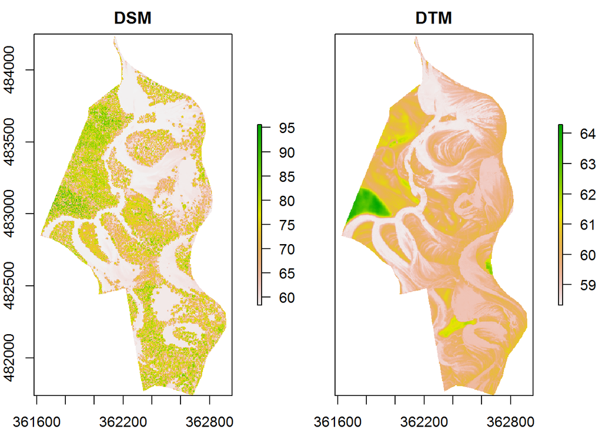

```r
plot(DEM)
```

Teraz możemy obliczyć wysokość drzew i budynków.

```r
diffDEM = DEM[[1]] - DEM[[2]]
```

Ostatnim krokiem jest wizualizacja wyniku różnicy.

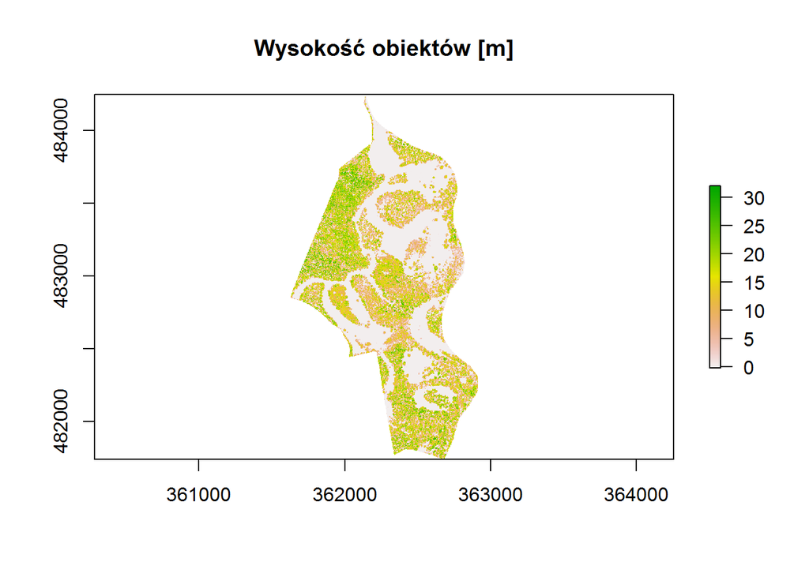

```r
plot(diffDEM, main = "Wysokość obiektów [m]")
```

# Informacje o rgugik

Strona projektu: https://kadyb.github.io/rgugik

GitHub: https://github.com/kadyb/rgugik/

Obsługiwane zbiory danych:

- ortofotomapa,
- Baza Danych Obiektów Ogólnogeograficznych (BDOO),
- Państwowy Rejestr Nazw Geograficznych (PRNG),
- geometria działek katastralnych,
- modele 3D budynków (LOD1, LOD2),
- Cyfrowe Modele Wysokościowe (NMT, NMPT, chmura punktów).
[^1]: Oprócz wymienionego sposobu pomocna jest również funkcja `View()`.
[^2]: Jego miejsce można sprawdzić funkcją `getwd()`